# Team.rmd

```r
library(dplyr)
```

```r
library(ggplot2)
install.packages('readxl', repos = "http://cran.us.r-project.org")
data <- readxl::read_excel('/Users/visma/Desktop/DS202/ds202_lab3/GSS.xls')
data
```

```
## # A tibble: 64,816 x 11
##    `Gss year for t~ `General happin~ `Political part~ `Respondents se~
##               <dbl> <chr>            <chr>            <chr>
##  1             1972 Not too happy    Ind,near dem     Female
##  2             1972 Not too happy    Not str democrat Male
##  3             1972 Pretty happy     Independent      Female
##  4             1972 Not too happy    Not str democrat Female
##  5             1972 Pretty happy     Strong democrat  Female
##  6             1972 Pretty happy     Ind,near dem     Male
##  7             1972 Not too happy    Ind,near dem     Male
##  8             1972 Not too happy    Ind,near dem     Male
##  9             1972 Pretty happy     Strong democrat  Female
## 10             1972 Pretty happy     Strong democrat  Female
## # ... with 64,806 more rows, and 7 more variables: `Highest year of school
## #   completed` <chr>, `Ever been divorced or separated` <chr>, `Marital
## #   status` <chr>, `Number of hours usually work a week` <chr>, `Labor force
## #   status` <chr>, `Respondent id number` <dbl>, `Ballot used for
## #   interview` <chr>
```

#Question 1

Find the average years of education for the respondents with each marital status. Arrange your output in a meaningful order and print. Describe any patterns you find.

```r
years <- as.numeric(data$`Highest year of school completed`)
data$years <- years
var1 <- data %>%
  group_by(`Marital status`) %>%
    summarize(AvgYr = mean(years, na.rm = TRUE)) %>%
      arrange(AvgYr)

var1
```

```
## # A tibble: 7 x 2
##   `Marital status` AvgYr
##   <chr>            <dbl>
## 1 Widowed           11.2
## 2 Separated         11.9
## 3 Married           13.0
## 4 Divorced          13.1
## 5 Never married     13.4
## 6 No answer         15.5
## 7 <NA>             NaN
```

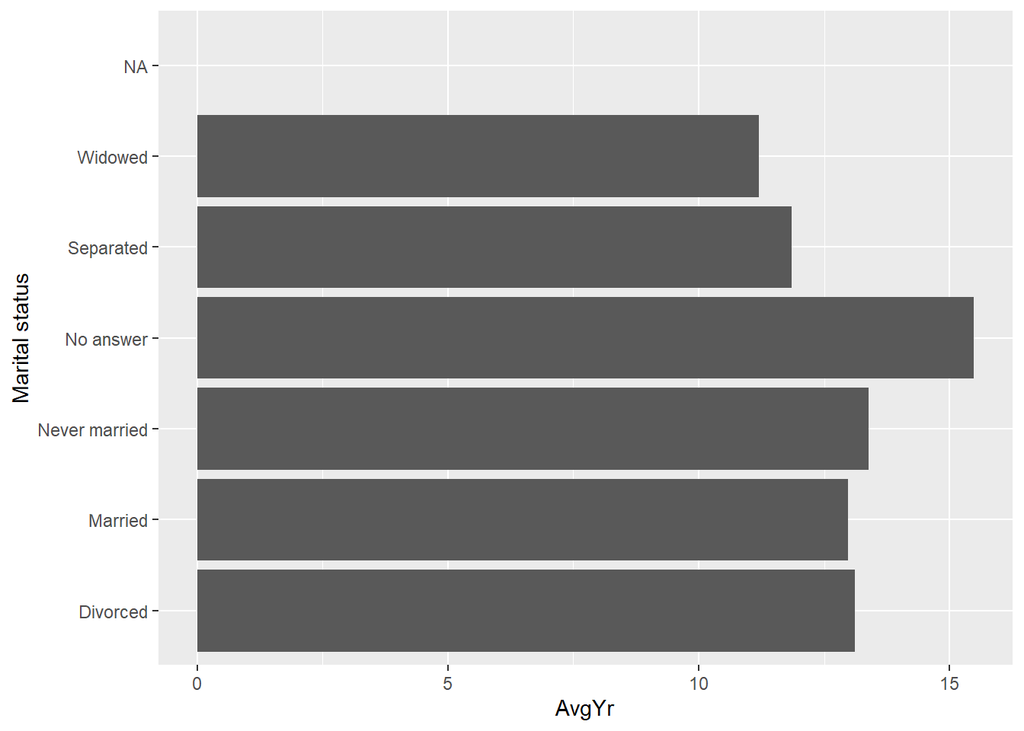

```r
ggplot(data = var1, aes(x = AvgYr, y = `Marital status`)) + geom_bar(stat="identity")
```

It is hard to define a specific pattern for the given data. Just by looking at the summary table, we can see that the group of ‘never married’ has the highest mean years of education compared to “divorced” or “married” group. However, it is hard to generalize the consequences between these variable since there is a group of “no answer”. The outcome will change if those group of “no answer” replies back. Hence, it is difficult for us to conclude that marital status affects the average years of education for the respondents.

Question 2

```r
##For No Answer
nAns <- data.frame(data[data$`Marital status` %in% c('No answer'), ])
nAns<- na.omit(nAns)
AvgNAns <- mean(nAns$years)
FNAns <- nAns[!nAns$years < AvgNAns, ]

##For Never Married
nm <- data.frame(data[data$`Marital status` %in% c('Never married'), ])
nm<- na.omit(nm)
AvgNM <- mean(nm$years)
FNM <- nm[!nm$years < AvgNM, ]

##For Divorced
d <- data.frame(data[data$`Marital status` %in% c('Divorced'), ])
d<- na.omit(d)
AvgD <- mean(d$years)
FD <- d[!d$years < AvgD, ]

##For Married
m <- data.frame(data[data$`Marital status` %in% c('Married'), ])
m<- na.omit(m)
AvgM <- mean(m$years)
FM <- m[!m$years < AvgM, ]

##For Separated
s <- data.frame(data[data$`Marital status` %in% c('Separated'), ])
s<- na.omit(s)
AvgS <- mean(s$years)
FS <- s[!s$years < AvgS, ]

##For Widowed
w <- data.frame(data[data$`Marital status` %in% c('Widowed'), ])
w<- na.omit(w)
AvgW <- mean(w$years)
FW <- w[!w$years < AvgW, ]

FinalDF <- rbind(FNAns, FNM, FD, FM, FS, FW)
FinalDF
```

```
##        Gss.year.for.this.respondent General.happiness
## 3                              1990      Pretty happy
## 4                              1993        Very happy
## 5                              1994        Don't know
## 6                              1996         No answer
## 12                             2006    Not applicable
## 15                             2008        Very happy
## 16                             2008     Not too happy
## 17                             2008     Not too happy
## 19                             2008      Pretty happy
## 21                             2014     Not too happy
## 22                             2014     Not too happy
## 23                             2014        Very happy
## 24                             2014      Pretty happy
## 27                             2018        Very happy
```

[output cut: 41656 more lines]

Question 3

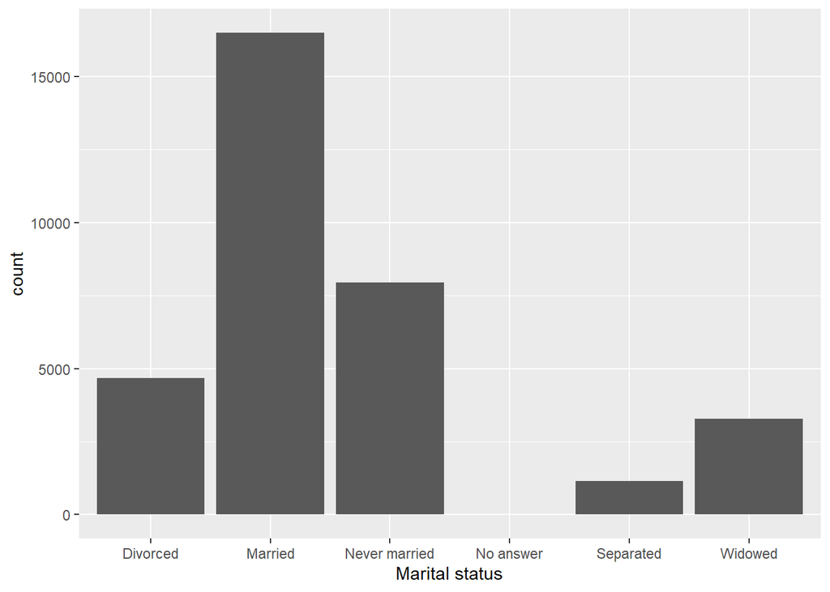

```r
happy <- filter(data, `General happiness` == "Pretty happy" | `General happiness` == "Very Happy")
ggplot(happy, aes(x = `Marital status`)) + geom_histogram(stat = "count")
```

```r
data %>%
  select(`General happiness`, `Marital status`) %>%
    group_by(`Marital status`) %>%
      count(`General happiness`)
```

```
## # A tibble: 38 x 3
## # Groups:   Marital status [7]
##    `Marital status` `General happiness`     n
##    <chr>            <chr>               <int>
##  1 Divorced         Don't know              3
##  2 Divorced         No answer              58
##  3 Divorced         Not applicable        688
##  4 Divorced         Not too happy        1450
##  5 Divorced         Pretty happy         4683
##  6 Divorced         Very happy           1497
##  7 Married          Don't know             12
##  8 Married          No answer             123
##  9 Married          Not applicable       2221
## 10 Married          Not too happy        2431
## # ... with 28 more rows
```

We can see from the graphs above that people who are married tend to be happier than people who are widowed or those with failed relationships. The second happiest people are those who never married, followed by those that are divorced. The least happiest people are the ones who are separated.